# Biometry Midterm (Parts 2 & 3)

#### 10/13/26

## Part 1: Writing about Data

```r
# R script to load in and clean CREMP Octo data for use in Biometry assignments

## Load packages and read in datasets--------------------------------------------
library(tidyverse)

octo_tally_master <- read.csv("https://raw.githubusercontent.com/caroline-link/Biometry/refs/heads/main/CREMP_OCTO_Data/CREMP_OCTO_Tallies_Masterfile.csv")

octo_conditions_master <- read.csv("https://raw.githubusercontent.com/caroline-link/Biometry/refs/heads/main/CREMP_OCTO_Data/CREMP_OCTO_Condition_Masterfile.csv")



## Clean tally dataset-----------------------------------------------------------

###Subset to observations from 2012-2025 and rename "Subregion" column to "SubRegion"
tally <- octo_tally_master |>
         filter(SampleYear > 2011) |>
         rename(SubRegion = Subregion)



## Clean conditions dataset------------------------------------------------------

### Subset to observations from 2012-2025 and rename column names to match tally dataset
conditions <- octo_conditions_master |>
              filter(SampleYear > 2011) |>
              rename(SubRegion = subRegionId,
                      Habitat = habitatid,
                      SiteCode = Site.Code,
                      SiteID = siteid,
                      SiteName = sitename,
                      Height_cm = Height.cm.)

### Limit to current CREMP target species, update species codes (including combining NS-PAME and PAME)
conditions_targets <- conditions |>
                      filter(SPP_Code %in% c("PAME",
                                             "NS-PAME",
                                             "PFLE",
                                             "GVEN",
                                             "PBIP",
                                             "PPOR")) |>
                      mutate(SPP_Code = recode(SPP_Code,
                                               "NS-PAME" = "AAME",
                                               "PAME" = "AAME",
                                               "PFLE" = "EFLE",
                                               "PBIP" = "ABIP"))
```

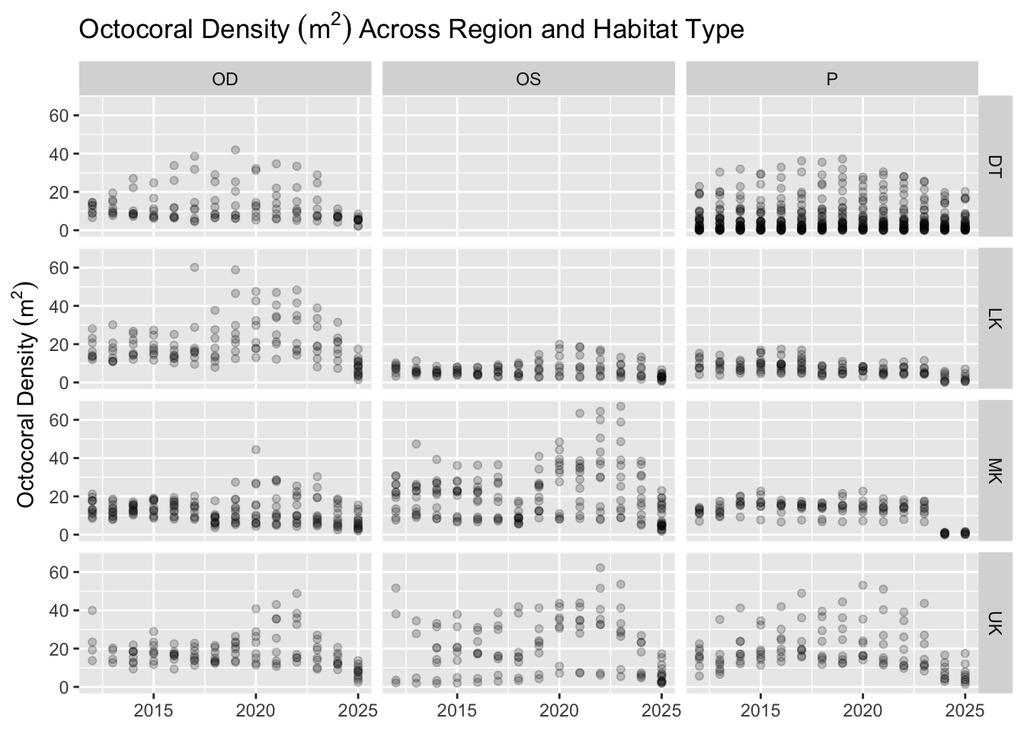

```r
# Code for Figure 1
tally |>
  group_by(SubRegion, SampleYear, Habitat) |>
  ggplot(tally, mapping = aes(x = SampleYear,
                              y = Density)) +
  geom_point(alpha = 0.2) +
  facet_grid(SubRegion ~ Habitat) +
  labs(title = bquote("Octocoral Density" ~(m^2)~"Across Region and Habitat Type"),
       y = bquote("Octocoral Density" ~(m^2))) +
  theme(axis.title.x = element_blank())
```

```
## `summarise()` has regrouped the output.
## ℹ Summaries were computed grouped by SPP_Code and SampleYear.
## ℹ Output is grouped by SPP_Code.
## ℹ Use `summarise(.groups = "drop_last")` to silence this message.
## ℹ Use `summarise(.by = c(SPP_Code, SampleYear))` for per-operation grouping
##   (`?dplyr::dplyr_by`) instead.
```

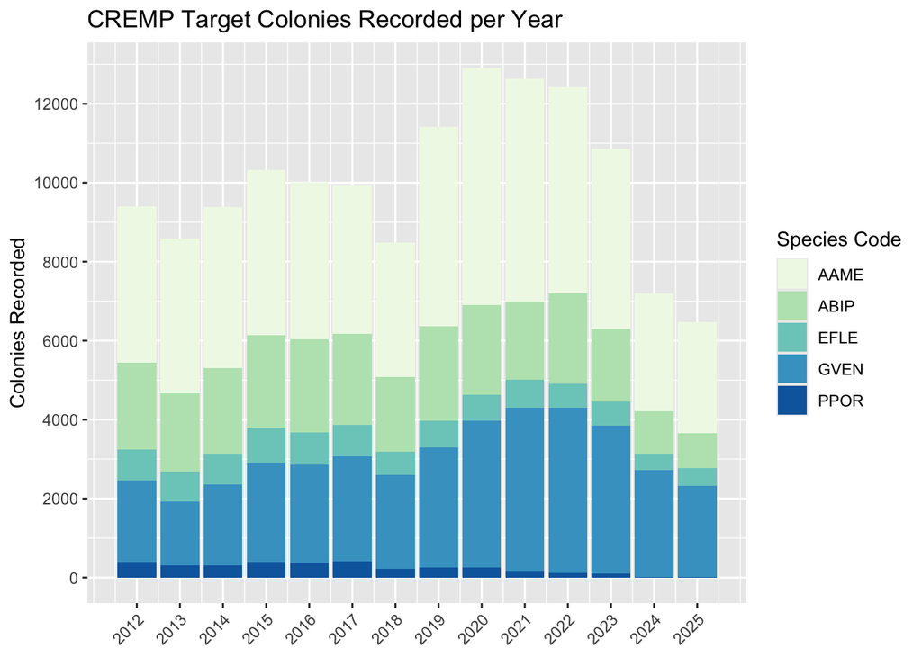

```r
# Code for Figure 2
conditions_targets |>
  group_by(SPP_Code, SampleYear) |>
  summarise(total_colonies = n()) |>
  ggplot(mapping = aes(x = SampleYear,
                       y = total_colonies,
                       fill = SPP_Code)) +
  geom_bar(stat = "identity") +
  labs(title = "CREMP Target Colonies Recorded per Year",
       y = "Colonies Recorded",
       fill = "Species Code") +
  scale_x_continuous(breaks = seq(2012, 2025, seq = 1)) +
  theme(axis.text.x = element_text(angle=45, hjust = 1)) +
  scale_y_continuous(n.breaks = 10) +
  scale_fill_brewer(palette = "GnBu") +
  theme(axis.title.x = element_blank())
```

## Part 2: Functions and Distribution

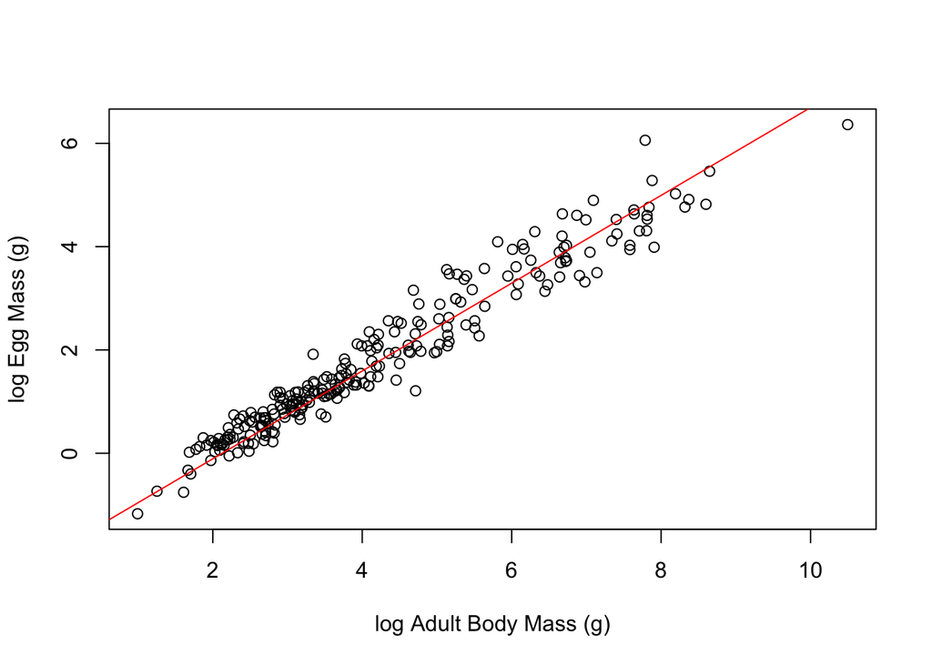

```r
# Load Amniote Life History Database
twoa <- read_rds("https://github.com/bmaitner/biometry_course/raw/refs/heads/main/midterm/b_2a.RDS")

# Plot scatter plot of predictor vs response variable
plot(log(twoa$Adult.Body.Mass.g), log(twoa$Egg.Mass.g),
     xlab = "log Adult Body Mass (g)",
     ylab = "log Egg Mass (g)")

# Add linear line to scatterplot
abline(a = log(2) - 2.5, b = 0.85, col = "red")
```

```r
# Plot density histogram for response variable
hist(log(twoa$Egg.Mass.g), breaks = 15, freq = FALSE,
     main = "",
     xlab = "log Egg Mass (g)")

# Calculate mean, median, and sd of log-transformed Egg Mass
mean(log(twoa$Egg.Mass.g))
```

```
## [1] 1.848468
```

```r
median(log(twoa$Egg.Mass.g))
```

```
## [1] 1.366062
```

```r
sd(log(twoa$Egg.Mass.g))
```

```
## [1] 1.484682
```

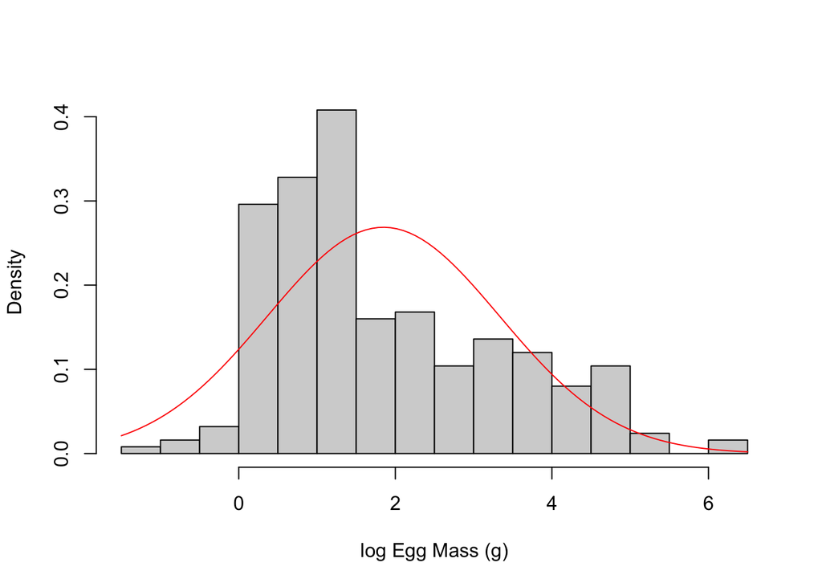

```r
# Add distribution curve to histogram
curve(dnorm(x, mean = mean(log(twoa$Egg.Mass.g)), sd = sd(log(twoa$Egg.Mass.g))),
            add = TRUE, col = "red")
```

- I believe that the relationship between adult body mass (g) and egg mass (g) of birds in the Amniote Life History Database would be well described by a power law function because it’s relatively linear when plotted on log-log scaled axis. It also makes biological sense that egg mass (and assumedly egg size) would increase relative to adult body mass. Since egg mass is a continuous variable who’s distribution becomes more symmetric after log transformation, it would be best described with a lognormal distribution.

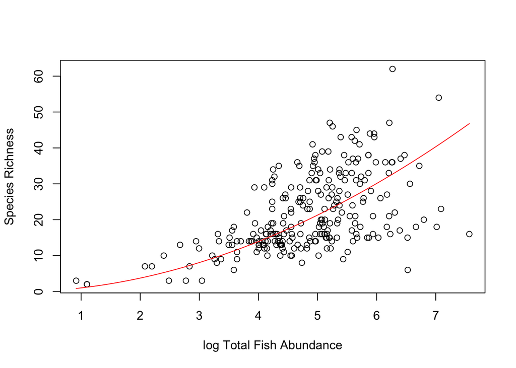

```r
# Load NOAA NCREMP data
twob <- read_rds("https://github.com/bmaitner/biometry_course/raw/refs/heads/main/midterm/b_2b.RDS")

# Plot scatter plot of predictor vs response variable
plot(log(twob$Total.Fish.Abundance), twob$Species.Richness,
     xlab = "log Total Fish Abundance",
     ylab = "Species Richness")

# Add exponential function to scatter plot
exponential <- function(x, a, b){
            a * x ^ b
}

curve(exponential(x, a = 1, b = 1.9), add = TRUE, col = "red")
```

```r
# Plot density histogram for response variable
hist(twob$Species.Richness, breaks = 15, freq = FALSE,
     main = "",
     xlab = "Species Richness")

# Calculate mean, median, and var of species richness
mean(twob$Species.Richness)
```

```
## [1] 21.784
```

```r
median(twob$Species.Richness)
```

```
## [1] 19
```

```r
var(twob$Species.Richness)
```

```
## [1] 112.5556
```

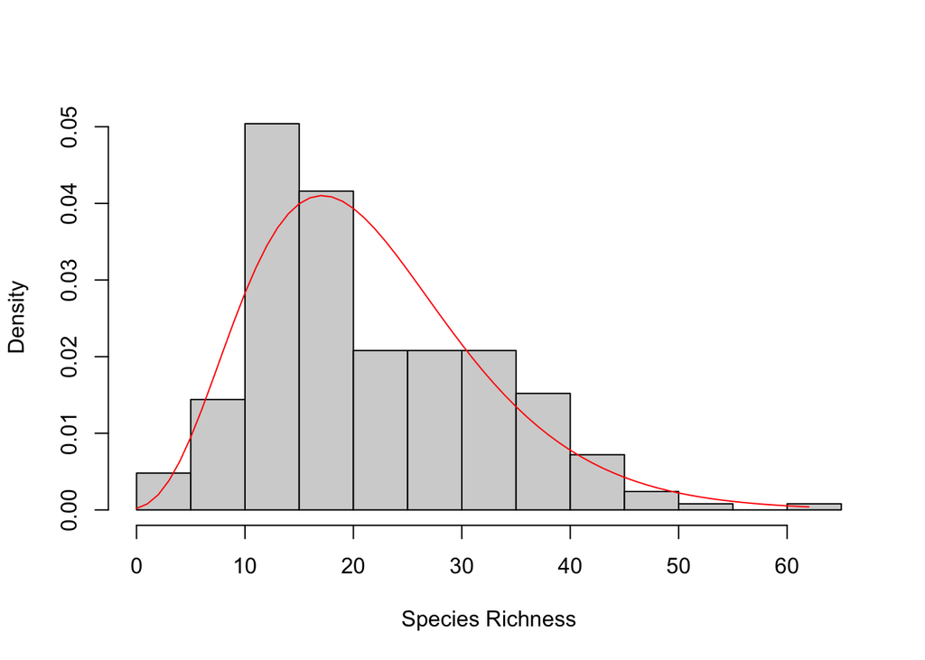

```r
# Define parameters and add distribution curve to histogram
mu <- mean(twob$Species.Richness)
size <- mu^2 / (var(twob$Species.Richness) - mu)


curve(dnbinom(x, mu = mu, size = size),
      from = 0,
      to = max(twob$Species.Richness),
      n = (max(twob$Species.Richness) + 1),
      add = TRUE, col = "red")
```

- In the NOAA NCREMP data, there appears to be a positive exponential relationship between the total abundance of fish and the number of species recorded on a survey. While the data don’t perfectly match the exponential curve, it follows general biological reasoning that species richness would generally increase with fish abundance. As species richness is a discrete variable, theoretically unbounded, with a mean that is much smaller than the variance, it’s distribution would be well described as a negative binomial.

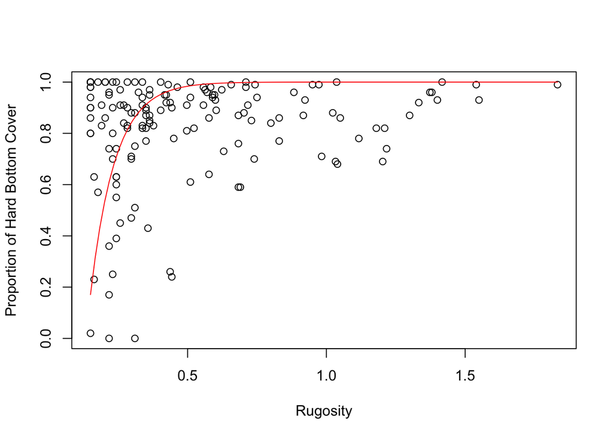

```r
# Reef Rugosity
twoc <- read_rds("https://github.com/bmaitner/biometry_course/raw/refs/heads/main/midterm/b_2c.RDS")

# Plot scatter plot of predictor vs response variable
plot(twoc$Rugosity, (twoc$Hard.Bottom.Cover.Pct/100),
     xlab = "Rugosity",
     ylab = "Proportion of Hard Bottom Cover")

# Define parameters and add monomolecular to scatter plot
mono <- function(x, a, b , c){
            a * (1 - exp(-b * (x - c)))
}
curve(mono(x * .75, a = 1, b = 15, c = 0.1), add = TRUE, col = "red")
```

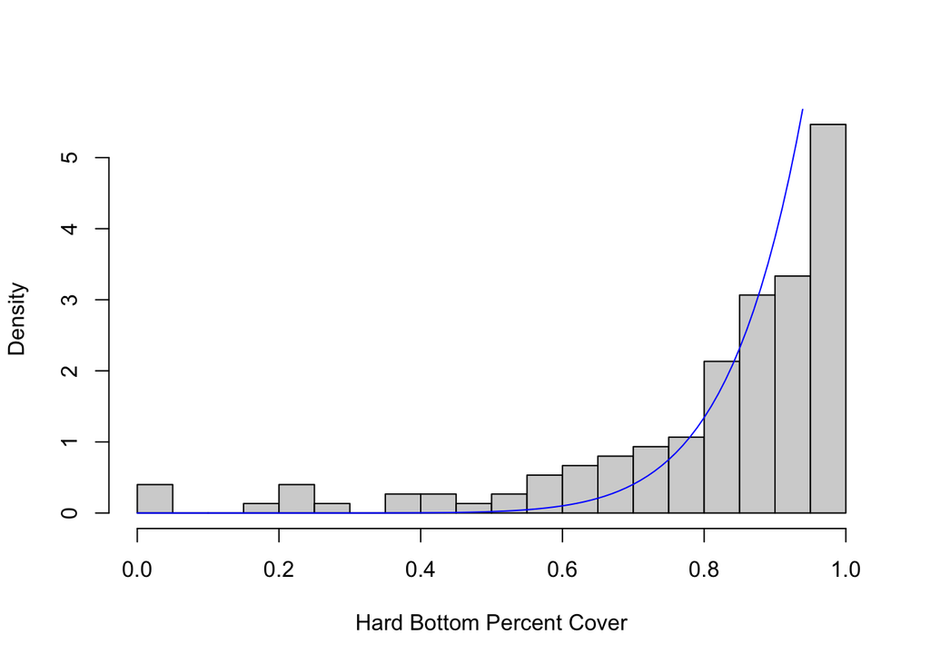

```r
# Plot density histogram for response variable
hist((twoc$Hard.Bottom.Cover.Pct/100), breaks = 15, freq = FALSE,
     main = "",
     ylab = "Density",
     xlab = "Hard Bottom Percent Cover")

# Add distribution curve to histogram
curve(dbeta(x, shape1 = 10, shape2 = 1), add = TRUE, col = "blue")
```

- I believe that the relationship between reef rugosity and the percentage (converted to a proportion in this plot) of a site covered by hard bottom generally follows a monomolecular function because the data appear to follow a quickly saturating curve without a clear inflection point. An argument could also be made for a threshold function because sites with rugosities of 0 to ~ 0.5 have a proportion of harbottom cover ranging from 0 - 1, while sites with rugosities above 0.5 all have a harbottom cover proportion of 0.5 or greater. Since hardbottom cover is a continuous variable represented by a proportion ranging from 0 to 1, it is well described by a left-skewed beta distribution.

## Part 3: Power Analysis

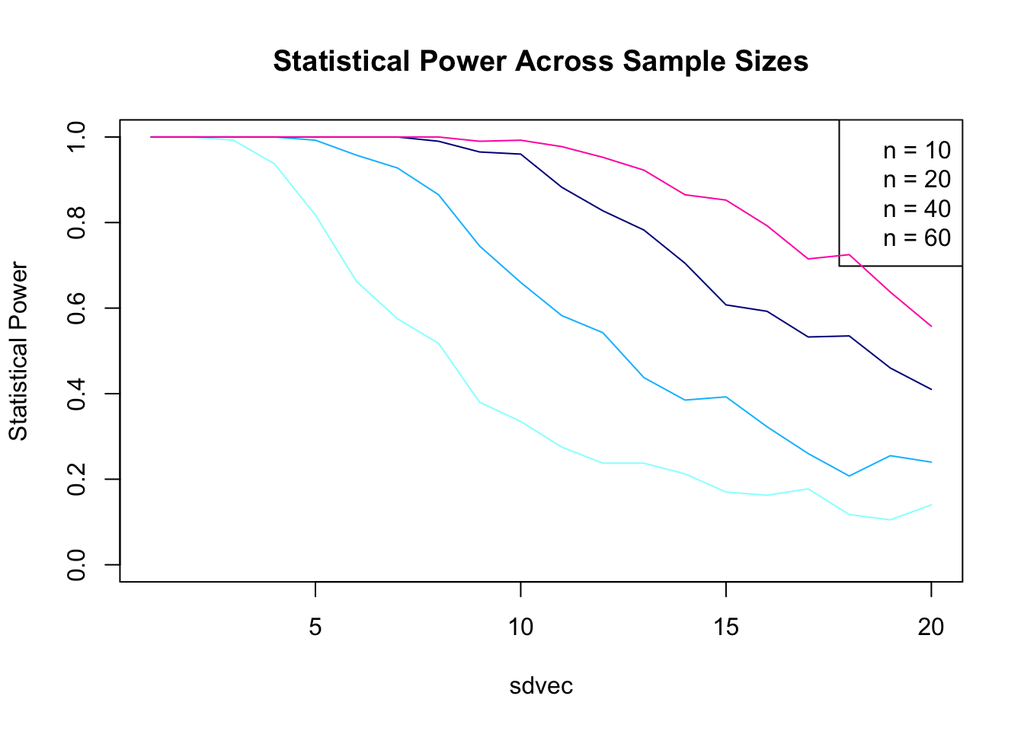

```r
sample_sizes <- c(10, 20, 40, 60)
a <- 2
b <- 1

nsim <- 400
sdvec <- seq(1, 20, by = 1)
power.sd <- numeric(length(sdvec))
pval <- numeric(nsim)

# Create matrix to store results
matrix <- matrix(NA, nrow = length(sdvec), ncol = length(sample_sizes))
colnames(matrix) <- paste0("n_", sample_sizes)

# Create a blank base plot
plot(sdvec, matrix[,1],
     type = "n",
     ylim = c(0,1),
     main = "Statistical Power Across Sample Sizes",
     ylab = "Statistical Power")

legend("topright",
       legend = paste("n =", sample_sizes),
       col = c("darkslategray1", "deepskyblue", "darkblue", 'maroon1'))

for( k in 1:length(sample_sizes)){
  sample_size <- sample_sizes[k]

  for(j in 1:length(sdvec)){
   for(i in 1:nsim){

     x <- sample(x = 1:20,
                 size = sample_size,
                 replace = TRUE)

     sd <- sdvec[j]
     y_det <- a + b*x
     y <- rnorm(n = length(y_det),
                mean = y_det,
                sd = sd)

       m <- lm(y ~ x)

      #get p-value

     pval[i] <- coef(summary(m))["x","Pr(>|t|)"]

    }#end i loop
    matrix[j,k] <- sum(pval < 0.05)/nsim

  }#end j loop
  line_colors <- c("darkslategray1", "deepskyblue", "darkblue", 'maroon1')

  lines(sdvec, matrix[,k],
        col = line_colors[k])
} #end k loop
```

- The statistical power of a model is highest when there is little variance in the data and decreases as noise (sdvec) increases. The sample size impacts the starting point and rate of this decline, and therefore impacts how much noise the model can withstand before loosing statistical power. As illustrated above, noise has a more significant effect on power and a researcher looking to increase the statistical power of their survey would be better served by halving their measurement error as opposed to doubling sample size.